```python
import pandas as pd
import numpy as np
import matplotlib.pyplot as plt
import seaborn as sns
```

# Data Loading

```python
file_1 = "Dataset/raw/Medibuddy insurance data personal details.csv"
file_2 = "Dataset/raw/Medibuddy Insurance Data Price.csv"

df1 = pd.read_csv(file_1)
df2 = pd.read_csv(file_2)
```

```python
df1.head(), df2.head()
df1.info()
df2.info()
```

```
<class 'pandas.core.frame.DataFrame'>
RangeIndex: 1338 entries, 0 to 1337
Data columns (total 4 columns):
 #   Column     Non-Null Count  Dtype
---  ------     --------------  -----
 0   Policy_No  1338 non-null   object
 1   Children   1338 non-null   int64
 2   Smoker     1338 non-null   object
 3   Region     1338 non-null   object
dtypes: int64(1), object(3)
memory usage: 41.9+ KB
<class 'pandas.core.frame.DataFrame'>
RangeIndex: 1338 entries, 0 to 1337
Data columns (total 5 columns):
 #   Column          Non-Null Count  Dtype
---  ------          --------------  -----
 0   Policy_No       1338 non-null   object
 1   Age             1338 non-null   int64
 2   Sex             1338 non-null   object
 3   BMI             1338 non-null   float64
 4   Charges_In_INR  1338 non-null   float64
dtypes: float64(2), int64(1), object(2)
memory usage: 52.4+ KB
```

# Merge Datasets

```python
df = pd.merge(df1, df2, on="Policy_No", how="inner")
```

```python
print(df.shape)
df.head()
```

```
(1338, 8)
```

|  | Policy_No | Children | Smoker | Region | Age | Sex | BMI | Charges_In_INR |
| --- | --- | --- | --- | --- | --- | --- | --- | --- |
| 0 | PLC157006 | 0 | no | southwest | 23 | male | 34.4 | 1826.843 |
| 1 | PLC157033 | 1 | no | southwest | 19 | male | 24.6 | 1837.237 |
| 2 | PLC157060 | 0 | no | southwest | 56 | male | 40.3 | 10602.385 |
| 3 | PLC157087 | 1 | no | southwest | 30 | female | 32.4 | 4149.736 |
| 4 | PLC157186 | 5 | no | southwest | 19 | female | 28.6 | 4687.797 |

# Data Quality Checks

```python
# Missing values
df.isnull().sum()
```

```
Policy_No         0
Children          0
Smoker            0
Region            0
Age               0
Sex               0
BMI               0
Charges_In_INR    0
dtype: int64
```

```python
# Duplicate policies
df.duplicated(subset="Policy_No").sum()
```

```
np.int64(0)
```

# Feature Engineering

```python
bmi_bins = [0, 18.5, 25, 30, 100]
bmi_labels = ['Underweight', 'Normal', 'Overweight', 'Obese']

age_bins = [0, 18, 30, 45, 60, 100]
age_labels = ['Teen', 'Young Adult', 'Adult', 'Middle Aged', 'Senior']


df['BMI_Group'] = pd.cut(
    df['BMI'],
    bins=bmi_bins,
    labels=bmi_labels,
    right=False
)

df['Age_Group'] = pd.cut(
    df['Age'],
    bins=age_bins,
    labels=age_labels,
    right=True
)
```

```python
df[['Age', 'Age_Group', 'BMI', 'BMI_Group']].head(10)
```

|  | Age | Age_Group | BMI | BMI_Group |
| --- | --- | --- | --- | --- |
| 0 | 23 | Young Adult | 34.4 | Obese |
| 1 | 19 | Young Adult | 24.6 | Normal |
| 2 | 56 | Middle Aged | 40.3 | Obese |
| 3 | 30 | Young Adult | 32.4 | Obese |
| 4 | 19 | Young Adult | 28.6 | Overweight |
| 5 | 26 | Young Adult | 20.8 | Normal |
| 6 | 55 | Middle Aged | 37.3 | Obese |
| 7 | 19 | Young Adult | 28.9 | Overweight |
| 8 | 61 | Senior | 39.1 | Obese |
| 9 | 53 | Middle Aged | 28.1 | Overweight |

```python
# Create Risk Score
df['Risk_Score'] = (
    (df['BMI'] >= 30).astype(int) +
    (df['Smoker'] == 'yes').astype(int) +
    (df['Age'] >= 50).astype(int)
)

# Risk Category
df['Risk_Level'] = pd.cut(
    df['Risk_Score'],
    bins=[-1, 1, 2, 3],
    labels=['Low Risk', 'Medium Risk', 'High Risk']
)
```

```python
df.describe()
```

|  | Children | Age | BMI | Charges_In_INR | Risk_Score |
| --- | --- | --- | --- | --- | --- |
| count | 1338.000000 | 1338.000000 | 1338.000000 | 1338.000000 | 1338.000000 |
| mean | 1.094918 | 39.207025 | 30.663397 | 13270.422265 | 1.020927 |
| std | 1.205493 | 14.049960 | 6.098187 | 12110.011237 | 0.804537 |
| min | 0.000000 | 18.000000 | 15.960000 | 1121.873900 | 0.000000 |
| 25% | 0.000000 | 27.000000 | 26.296250 | 4740.287150 | 0.000000 |
| 50% | 1.000000 | 39.000000 | 30.400000 | 9382.033000 | 1.000000 |
| 75% | 2.000000 | 51.000000 | 34.693750 | 16639.912515 | 2.000000 |
| max | 5.000000 | 64.000000 | 53.130000 | 63770.428010 | 3.000000 |

# Exporting Cleaned Dataset

```python
df.to_csv("medibuddy_cleaned_data.csv", index=False)
```

# CORRELATION

```python
# Encode categorical variables
df_corr = df.copy()
drop_cols = ['Policy_No', 'Age', 'BMI', 'Risk_Score', 'Risk_Level']
df_corr = df_corr.drop(drop_cols, axis=1)
df_corr['Sex'] = df_corr['Sex'].map({'male': 0, 'female': 1})
df_corr['Smoker'] = df_corr['Smoker'].map({'no': 0, 'yes': 1})
df_corr['BMI_Group'] = df_corr['BMI_Group'].map({'Underweight': 0, 'Normal': 1, 'Overweight': 2, 'Obese': 3})
df_corr['Age_Group'] = df_corr['Age_Group'].map({'Teen': 0, 'Young Adult': 1, 'Adult': 2, 'Middle Aged': 3, 'Senior': 4})
df_corr = pd.get_dummies(df_corr, columns=['Region'], drop_first=True)
```

```python
df_corr.head()
```

|  | Children | Smoker | Sex | Charges_In_INR | BMI_Group | Age_Group | Region_northwest | Region_southeast | Region_southwest |
| --- | --- | --- | --- | --- | --- | --- | --- | --- | --- |
| 0 | 0 | 0 | 0 | 1826.843 | 3 | 1 | False | False | True |
| 1 | 1 | 0 | 0 | 1837.237 | 1 | 1 | False | False | True |
| 2 | 0 | 0 | 0 | 10602.385 | 3 | 3 | False | False | True |
| 3 | 1 | 0 | 1 | 4149.736 | 3 | 1 | False | False | True |
| 4 | 5 | 0 | 1 | 4687.797 | 2 | 1 | False | False | True |

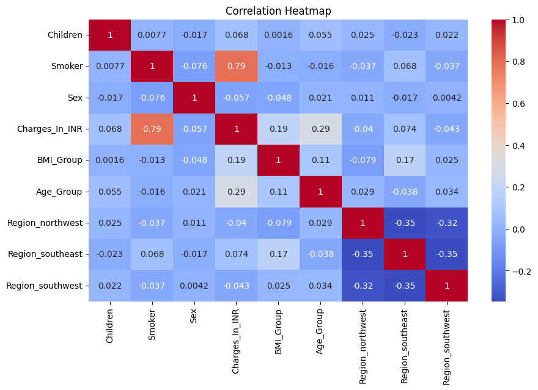

```python
# Correlation heatmap
plt.figure(figsize=(10,6))
sns.heatmap(df_corr.corr(), annot=True, cmap='coolwarm')
plt.title("Correlation Heatmap")
plt.show()
```

# Distribution of the Columns

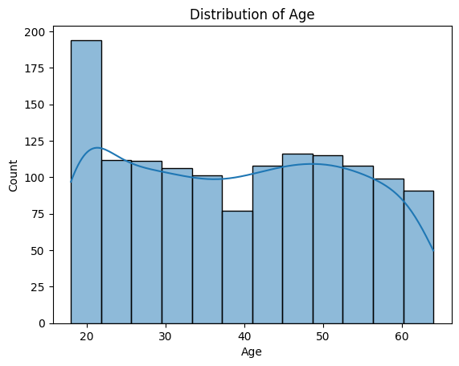

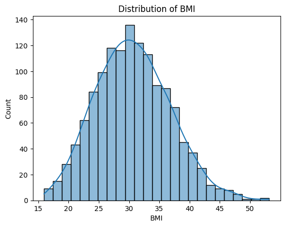

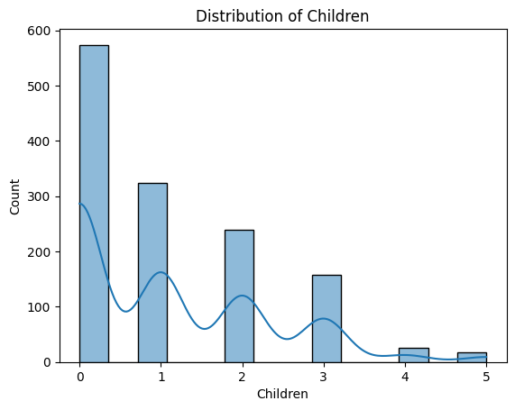

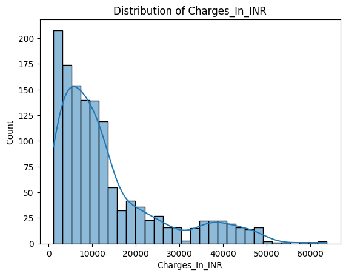

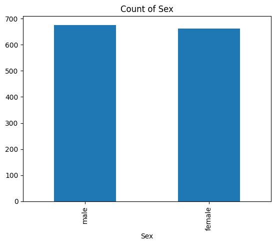

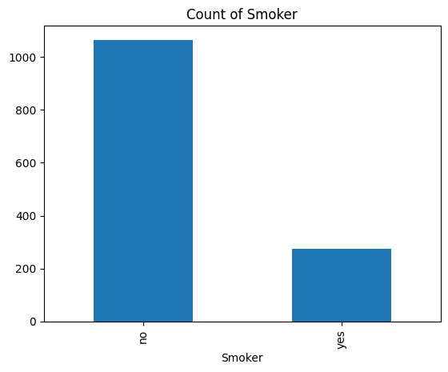

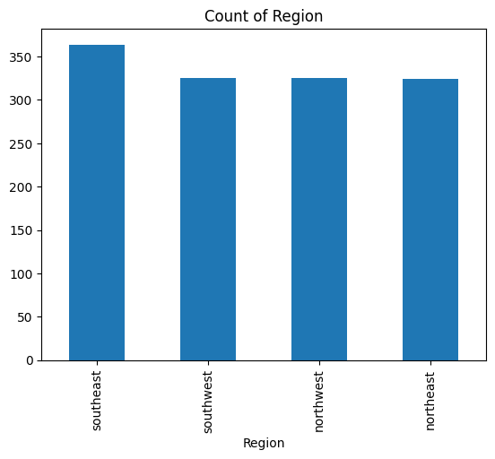

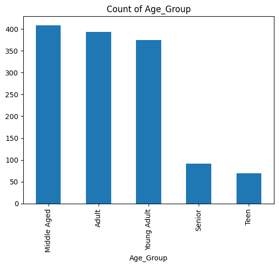

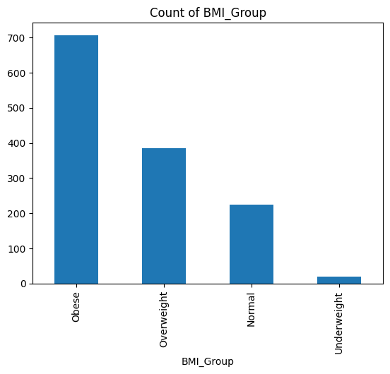

```python
# Numerical distributions
num_cols = ['Age', 'BMI', 'Children', 'Charges_In_INR']

for col in num_cols:
    plt.figure()
    sns.histplot(df[col], kde=True)
    plt.title(f"Distribution of {col}")
    plt.show()

# Categorical distributions
cat_cols = ['Sex', 'Smoker', 'Region', 'Age_Group', 'BMI_Group']

for col in cat_cols:
    plt.figure()
    df[col].value_counts().plot(kind='bar')
    plt.title(f"Count of {col}")
    plt.show()
```

Conclusion:

1. BMI values are right-skewed, with a large portion falling into Overweight and Obese categories.
2. Policy charges are inversely proportion with the number of policy purchase, i.e., with the increase in policy price the number of purchase fall significantly.
3. Most policyholders have 0–2 children, suggesting a small-size family contitute major nnumber of policies.
4. Insurance charges show a strong right-skew, indicating a small group of very high-cost customers.
5. The customer base is mainly dominated by adults and middle-aged individuals.

# Exploratory Data Analysis

1. Age VS Charges

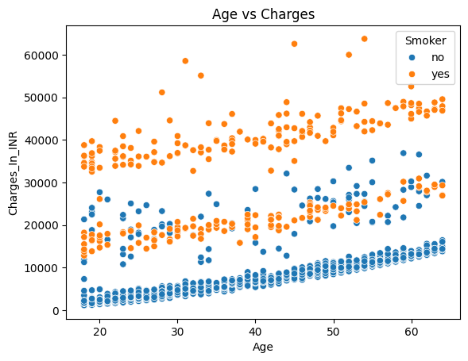

```python
plt.figure()
sns.scatterplot(x='Age', y='Charges_In_INR', hue='Smoker', data=df)
plt.title("Age vs Charges")
plt.show()
```

Conclusion : Insurance charges increase with age, especially after middle age.

2. BMI vs Charges based on smoking habits

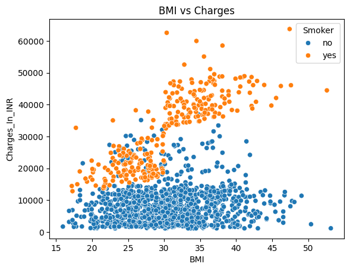

```python
plt.figure()
sns.scatterplot(x='BMI', y='Charges_In_INR', hue='Smoker', data=df)
plt.title("BMI vs Charges")
plt.show()
```

Conclusion :

- Smokers: With the increase in BMI the Policy carges increases
- Non-Smokers: There is no significant relation.
3. Charges by Sex

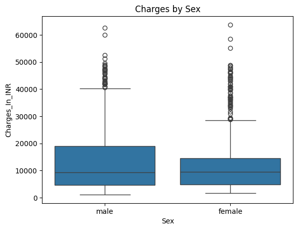

```python
plt.figure()
sns.boxplot(x='Sex', y='Charges_In_INR', data=df)
plt.title("Charges by Sex")
plt.show()
```

4. Charges by BMI Group

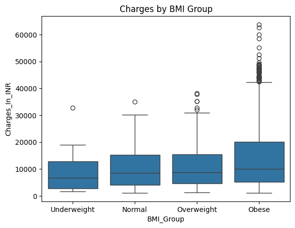

```python
plt.figure()
sns.boxplot(x='BMI_Group', y='Charges_In_INR', data=df)
plt.title("Charges by BMI Group")
plt.show()
```

5. Charges by Age Group + Smoker

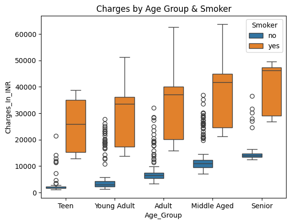

```python
plt.figure()
sns.boxplot(x='Age_Group', y='Charges_In_INR', hue='Smoker', data=df)
plt.title("Charges by Age Group & Smoker")
plt.show()
```

Conclusion :

- We see Policy charges tend to rise with age, significantly in later stages of life.
- Policy charges for people with smoking habits are significantly much higher than non-smokers.
6. Charges by BMI Group + Smoker

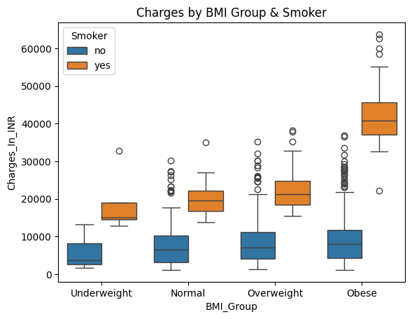

```python
plt.figure()
sns.boxplot(x='BMI_Group', y='Charges_In_INR', hue='Smoker', data=df)
plt.title("Charges by BMI Group & Smoker")
plt.show()
```

Conclusion : Policy charges are poisitively related to BMI. It is significantly higher for Obese Smokers.

7. Children + Age Group

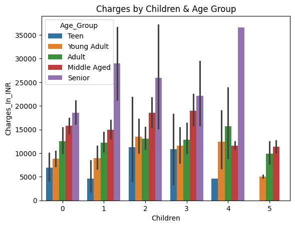

```python
plt.figure()
sns.barplot(x='Children', y='Charges_In_INR', hue='Age_Group', data=df)
plt.title("Charges by Children & Age Group")
plt.show()
```

Conclusion : Children count has a weak correlation, indicating limited direct cost impact.

8. Region Based Analysis

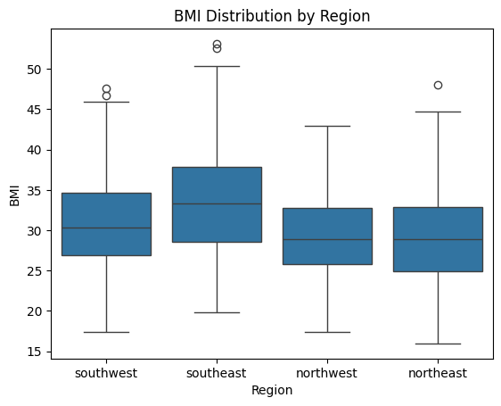

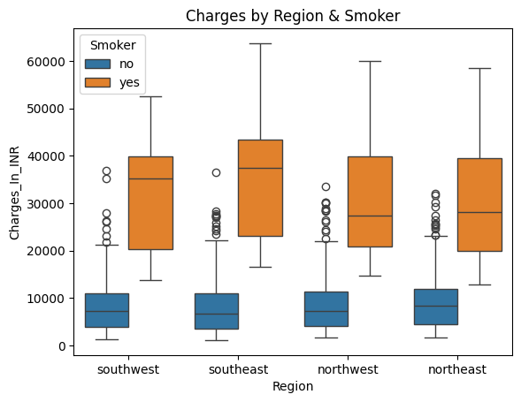

```python
# BMI distribution by region
plt.figure()
sns.boxplot(x='Region', y='BMI', data=df)
plt.title("BMI Distribution by Region")
plt.show()

# Charges by region & smoker
plt.figure()
sns.boxplot(x='Region', y='Charges_In_INR', hue='Smoker', data=df)
plt.title("Charges by Region & Smoker")
plt.show()
```

Conclusion : Region does not affect policy charges.

9. Risk Segmentation ANalysis

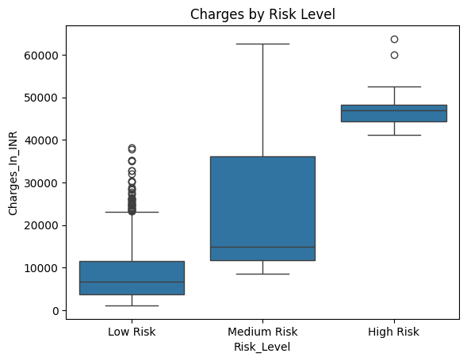

```python
# Charges by Risk Level
plt.figure()
sns.boxplot(x='Risk_Level', y='Charges_In_INR', data=df)
plt.title("Charges by Risk Level")
plt.show()
```

# Overall Conclusion :

The analysis reveals that lifestyle and health indicators—particularly smoking status, Age and BMI are the strongest predictors of policy charges, surpassing regional effects.